# DATA ANALYSIS OF PROSPER LOANS

### By Clifford Ijelekhai

### Investigation Overview

In this investigation, I want to look at the overall growth trend in the total amount of loans issued over the years, what affects the borrower’s APR or interest rate and if there are differences between loans depending on how large the original loan amount is. The focus would be on the loan original amount, borrowers APR and investors for the loan.

### Dataset Overview

The dataset has a record of 113937 loan applications with 81features. Most of the features are numeric while some are categorical. For this analysis 15 of the features were selected and records with missing values were dropped.

### Distribution of key features

I will be looking at these four key features in our dataset **BorrowerAPR, BorrowerRate, LoanOriginalAmount, Investors** to have insight into how they are distributed using a histogram.

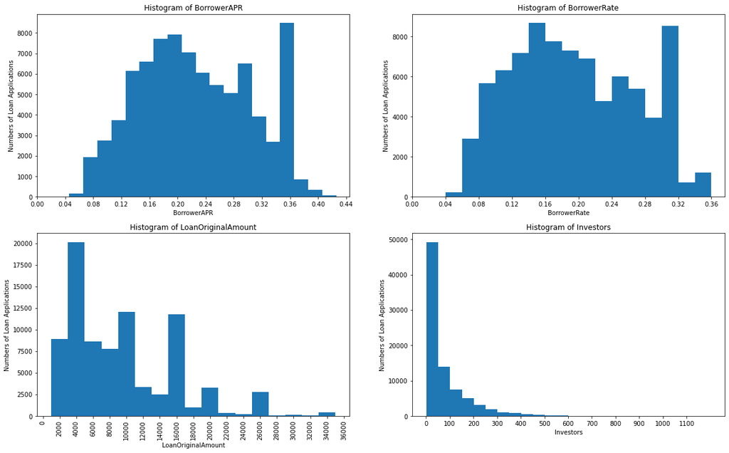

> **Histogram of BorrowerRate:** This appears to be bimodial, peaking at values between 0.14-0.16 and 0.30-0.32. Beyond 0.32, there is a steep fall in the numbers of loan application

> **Histogram of LoanOriginalAmount:** There is a high number of loan applications with values between 3000-4000dollars. As the Loan Original Amount increases, the numbers of loan applications drop. This can be seen on the histogram as it is skewed towards the right. A lot of people also apply for loans with values around 10,000dollars and 16,000dollars

> **Histogram of Investors:** The histogram is conspicuously skewed to the right. This is due to the presence of outliers. Where the usual case for the numbers of investors for a specific loan is less than 50, there appear to be an instance with over 1100 investors.

### Trends in the growth of Loan Amount

This we would found out by sorting the Loan Origination Date in ascending order and ploting a pointplot of LoanOriginalAmount against the LoanOriginationDate

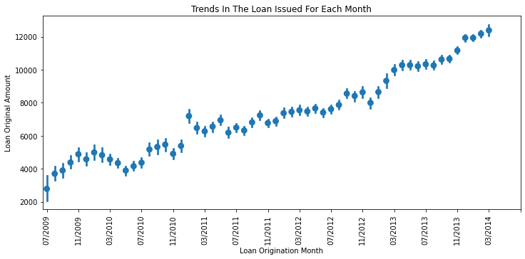

### Trends in the Lender Yield Over The Years

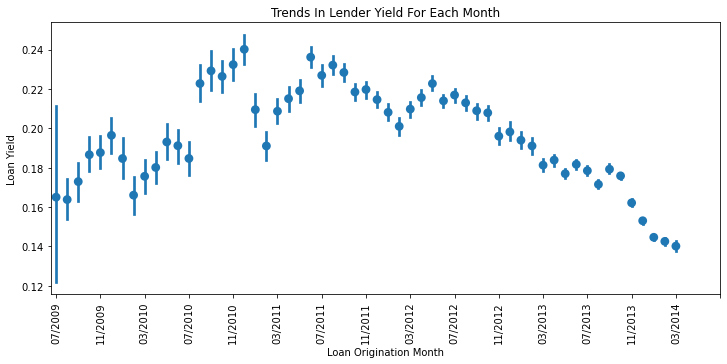

### Monthly Trend In Loan Amount For Each Income Range

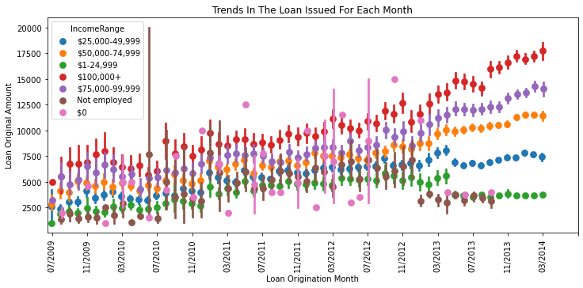

> Generally, there is an upward growth in the loan original amount from 2009 to 2014. However, for those with zero income, the loan original amount tends to fluctuate more between high and low. For income range of 100,000+ dollars, the loan original amount requested are higher than the rest.

### Factors that affects the borrower’s APR or interest rate?

To investigate this, we would visualize the relationship BorrowerAPR has with variables like LoanOriginalAmount, MonthlyLoanPayment, Investors, Term.

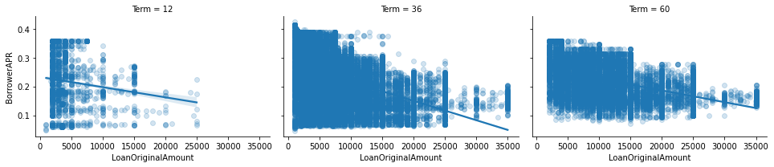

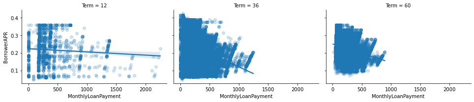

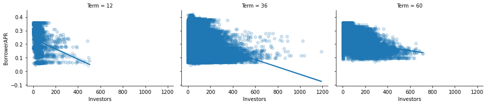

> From the figures above, we could see that as the loan original amount, monthly loan payment and investors increases, the BorrowerAPR reduces. However, there is a sharp reduction in interest rate for the 36months compared to the 12months and 60months loan.

### Are there differences between loans depending on how large the original loan amount was?

To investigate this, the loan original amount would be divided into three categories; small, medium and large loans.

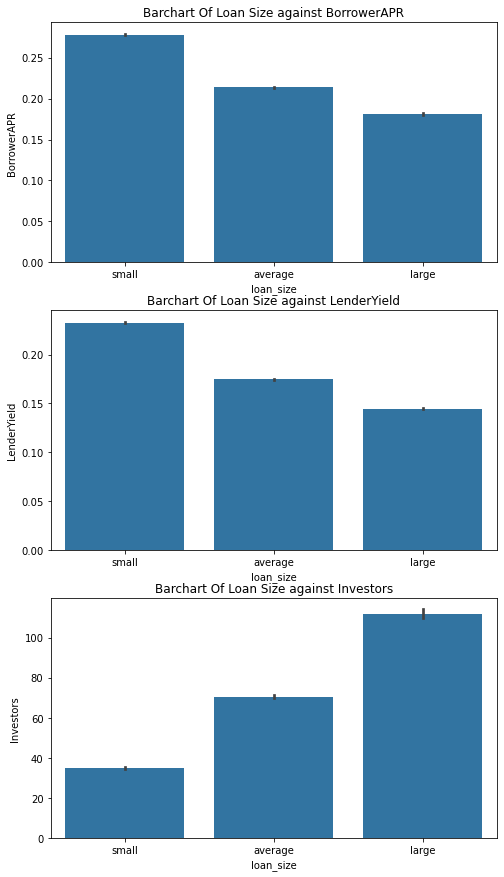

> There are differences between loan depending on large the original amount is. The barcharts of BorrowerAPR above reveals, the average interest rate for small loans is larger than that of large loans. The LenderYield for small loans is larger than that of large loans. While the number of investors need for small loans is smaller than that of large loan.